# Zajecia1

Bartlomiej Jamiolkowski

7 12 2021

# Zadanie 1

```r
library(SciViews)
library(ggplot2)
library(dplyr)
library(hrbrthemes)
```

```r
kgh_d_2009 <- read.csv("kgh_d_2009.csv", header = TRUE)
kgh_d_2012 <- read.csv("kgh_d_2012.csv", header = TRUE)
kgh_d_2020 <- read.csv("kgh_d_2020.csv", header = TRUE)
kgh_m_2009 <- read.csv("kgh_m_2009.csv", header = TRUE)
kgh_w_2012 <- read.csv("kgh_w_2012.csv", header = TRUE)
kgh_w_2020 <- read.csv("kgh_w_2020.csv", header = TRUE)
```

## Wykresy notowań spółki KGHM (kursy zamknięcia)

### Dane dzienne z lat 2012 - 2013

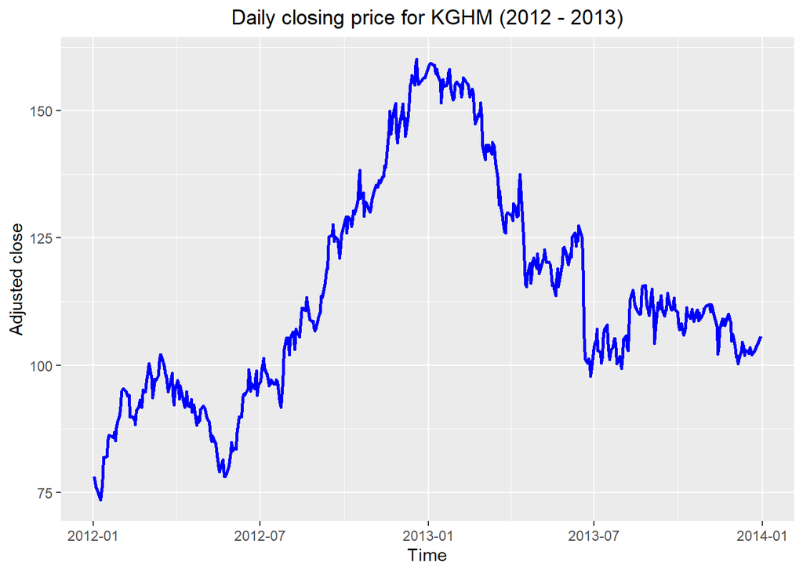

```r
ggplot(data = kgh_d_2012, aes(x = as.Date(Data), y = Zamkniecie)) +
  geom_line(color = "blue", size = 1) +
  ggtitle("Daily closing price for KGHM (2012 - 2013)") +
  theme(plot.title = element_text(hjust = 0.5)) +
  labs(x = "Time", y = "Adjusted close")
```

```r
# Simple daily rate return 2012 - 2013
close_d_2012 <- kgh_d_2012$Zamkniecie
rate_of_return_d_2012_s <- rep(0, 483)
for(i in 1:483){
  rate_of_return_d_2012_s[i] = 100 * (close_d_2012[i + 1] - close_d_2012[i])/close_d_2012[i]
}
# Logarithmic daily rate return 2012 - 2013
close_d_2012 <- kgh_d_2012$Zamkniecie
rate_of_return_d_2012_l <- rep(0, 483)
for(i in 1:483){
  rate_of_return_d_2012_l[i] = 100 * log(close_d_2012[i + 1]/close_d_2012[i])
}
```

### Dane tygodniowe dla lat 2012 - 2013

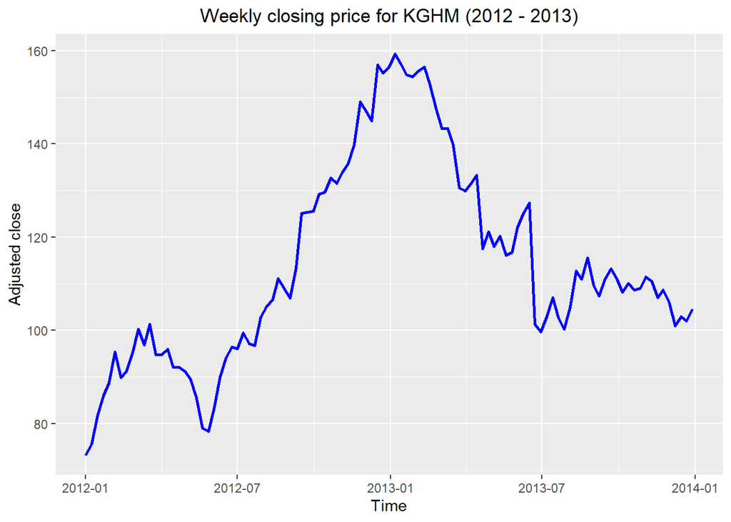

```r
ggplot(data = kgh_w_2012, aes(x = as.Date(Data), y = Zamkniecie)) +
  geom_line(color = "blue", size = 1) +
  ggtitle("Weekly closing price for KGHM (2012 - 2013)") +
  theme(plot.title = element_text(hjust = 0.5)) +
  labs(x = "Time", y = "Adjusted close")
```

```r
# Simple daily rate return 2012 - 2013
close_w_2012 <- kgh_w_2012$Zamkniecie
rate_of_return_w_2012_s <- rep(0, 483)
for(i in 1:483){
  rate_of_return_w_2012_s[i] = 100 * (close_w_2012[i + 1] - close_w_2012[i])/close_w_2012[i]
}
# Logarithmic daily rate return 2012 - 2013
close_w_2012 <- kgh_w_2012$Zamkniecie
rate_of_return_w_2012_l <- rep(0, 483)
for(i in 1:483){
  rate_of_return_w_2012_l[i] = 100 * log(close_w_2012[i + 1]/close_w_2012[i])
}
```

### Dane dzienne z lat 2020 - 2021

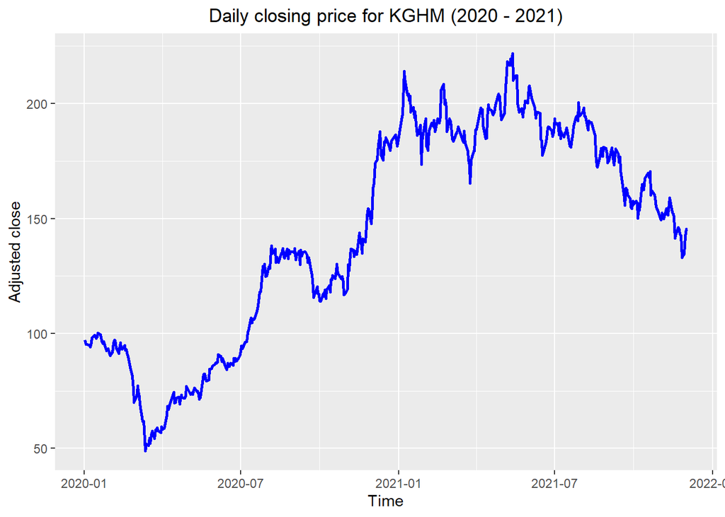

```r
ggplot(data = kgh_d_2020, aes(x = as.Date(Data), y = Zamkniecie)) +
  geom_line(color = "blue", size = 1) +
  ggtitle("Daily closing price for KGHM (2020 - 2021)") +
  theme(plot.title = element_text(hjust = 0.5)) +
  labs(x = "Time", y = "Adjusted close")
```

```r
# Simple daily rate return 2020 - 2021
close_d_2020 <- kgh_d_2020$Zamkniecie
rate_of_return_d_2020_s <- rep(0, 483)
for(i in 1:483){
  rate_of_return_d_2020_s[i] = 100 * (close_d_2020[i + 1] - close_d_2020[i])/close_d_2020[i]
}

# Logarithmic daily rate return 2020 - 2021
close_d_2020 <- kgh_d_2020$Zamkniecie
rate_of_return_d_2020_l <- rep(0, 483)
for(i in 1:483){
  rate_of_return_d_2020_l[i] = 100 * log(close_d_2020[i + 1] / close_d_2020[i])
}
```

### Dane tygodniowe dla lat 2020 - 2021

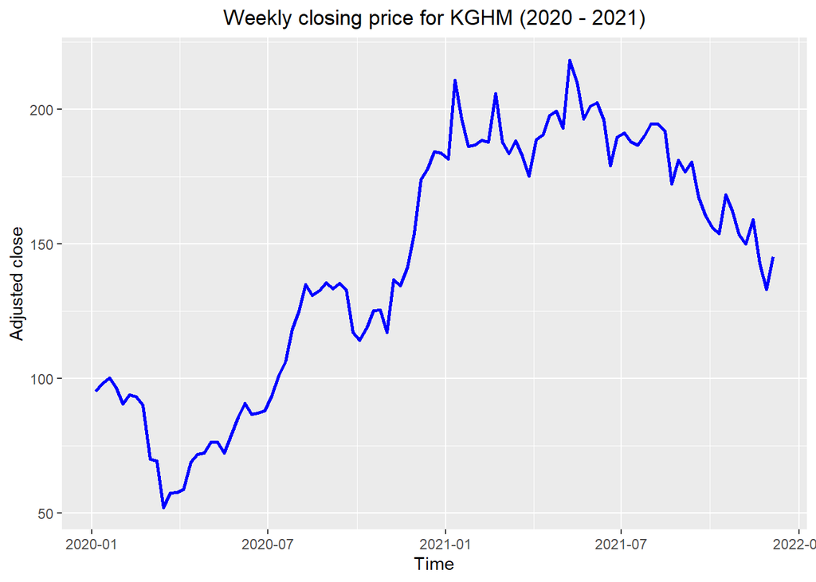

```r
ggplot(data = kgh_w_2020, aes(x = as.Date(Data), y = Zamkniecie)) +
  geom_line(color = "blue", size = 1) +
  ggtitle("Weekly closing price for KGHM (2020 - 2021)") +
  theme(plot.title = element_text(hjust = 0.5)) +
  labs(x = "Time", y = "Adjusted close")
```

```r
# Simple weekly rate return 2020 - 2021
close_w_2020 <- kgh_w_2020$Zamkniecie
rate_of_return_w_2020_s <- rep(0, 100)
for(i in 1:100){
  rate_of_return_w_2020_s[i] = 100 * (close_w_2020[i + 1] - close_w_2020[i])/close_w_2020[i]
}

# Logarithmic weekly rate return 2020 - 2021
close_w_2020 <- kgh_w_2020$Zamkniecie
rate_of_return_w_2020_l <- rep(0, 100)
for(i in 1:100){
  rate_of_return_w_2020_l[i] = 100 * log(close_w_2020[i + 1] / close_w_2020[i])
}
```

### Dane miesięczne z lat 2009 - 2021

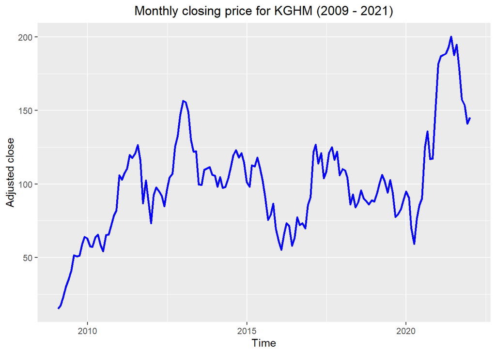

```r
ggplot(data = kgh_m_2009, aes(x = as.Date(Data), y = Zamkniecie)) +
  geom_line(color = "blue", size = 1) +
  ggtitle("Monthly closing price for KGHM (2009 - 2021)") +
  theme(plot.title = element_text(hjust = 0.5)) +
  labs(x = "Time", y = "Adjusted close")
```

```r
# Simple monthly rate return 2009 - 2021
close_m_2009 <- kgh_m_2009$Zamkniecie
rate_of_return_m_2009_s <- rep(0, 155)
for(i in 1:155){
  rate_of_return_m_2009_s[i] = 100 * (close_m_2009[i + 1] - close_m_2009[i])/close_m_2009[i]
}
# Logarithmic monthly rate return 2009 - 2021
close_m_2009 <- kgh_m_2009$Zamkniecie
rate_of_return_m_2009_l <- rep(0, 155)
for(i in 1:155){
  rate_of_return_m_2009_l[i] = 100 * log(close_m_2009[i + 1] / close_m_2009[i])
}
```

## Wykresy obu typów stóp zwrotu oraz wykres różnicy między stopą prostą i logarytmiczną

### Prosta dzienna stopa zwrotu z lat 2020 - 2021

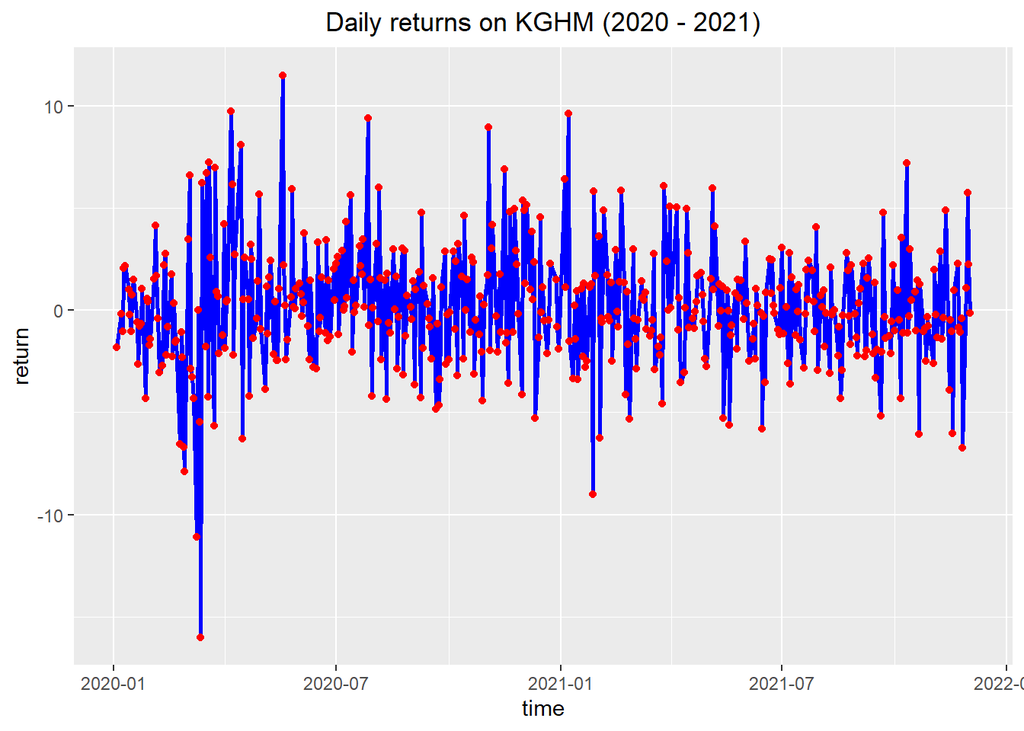

```r
data1 <- data.frame(
  day = as.Date(kgh_d_2020$Data[-1]),
  value = rate_of_return_d_2020_s
)

ggplot(data = data1, aes(x = day, y = value)) +
  geom_line(color = "blue", size = 1) +
  geom_point(color="red") +
  ggtitle("Daily returns on KGHM (2020 - 2021)") +
  theme(plot.title = element_text(hjust = 0.5)) +
  labs(x = "time", y = "return")
```

### Logarytmiczna dzienna stopa zwrotu z lat 2020 - 2021

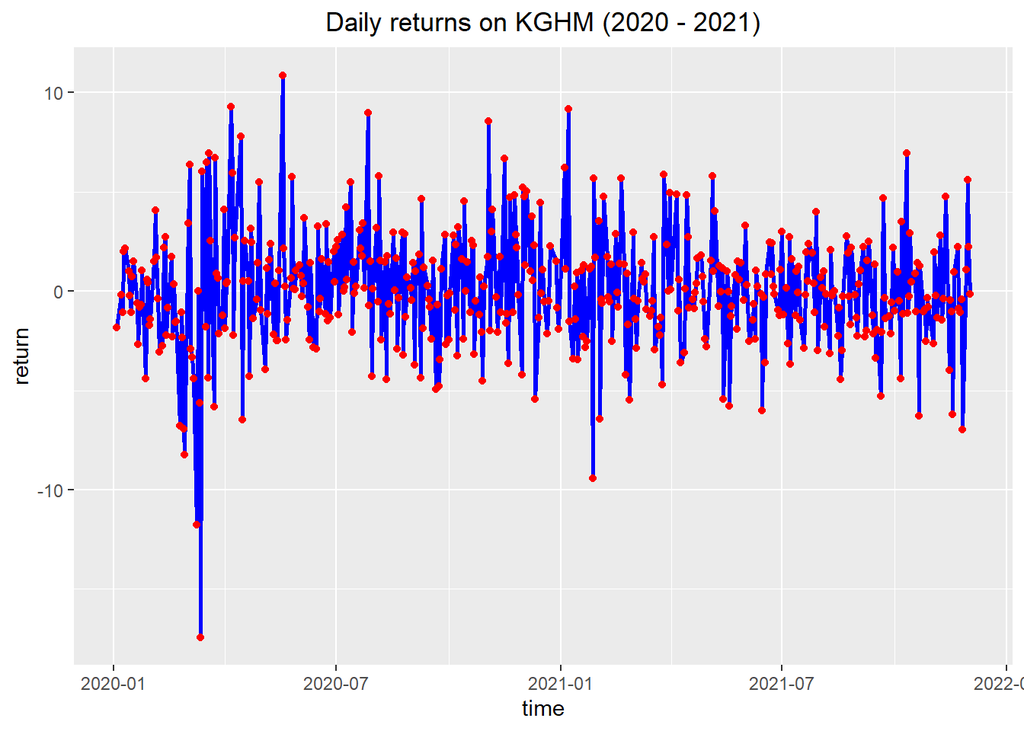

```r
data2 <- data.frame(
  day = as.Date(kgh_d_2020$Data[-1]),
  value = rate_of_return_d_2020_l
)

ggplot(data = data2, aes(x = day, y = value)) +
  geom_line(color = "blue", size = 1) +
  geom_point(color="red") +
  ggtitle("Daily returns on KGHM (2020 - 2021)") +
  theme(plot.title = element_text(hjust = 0.5)) +
  labs(x = "time", y = "return")
```

### Różnica między dzienna stopą prostą i logarytmiczną z lat 2020 - 2021

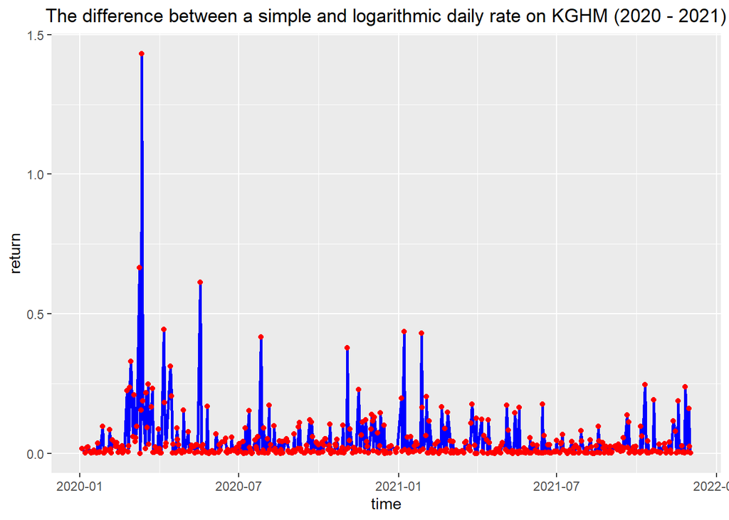

```r
data3 <- data.frame(
  day = as.Date(kgh_d_2020$Data[-1]),
  value = rate_of_return_d_2020_s - rate_of_return_d_2020_l
)

ggplot(data = data3, aes(x = day, y = value)) +
  geom_line(color = "blue", size = 1) +
  geom_point(color="red") +
  ggtitle("The difference between a simple and logarithmic daily rate on KGHM (2020 - 2021)") +
  theme(plot.title = element_text(hjust = 0.5)) +
  labs(x = "time", y = "return")
```

### Prosta tygodniowa stopa zwrotu z lat 2020 - 2021

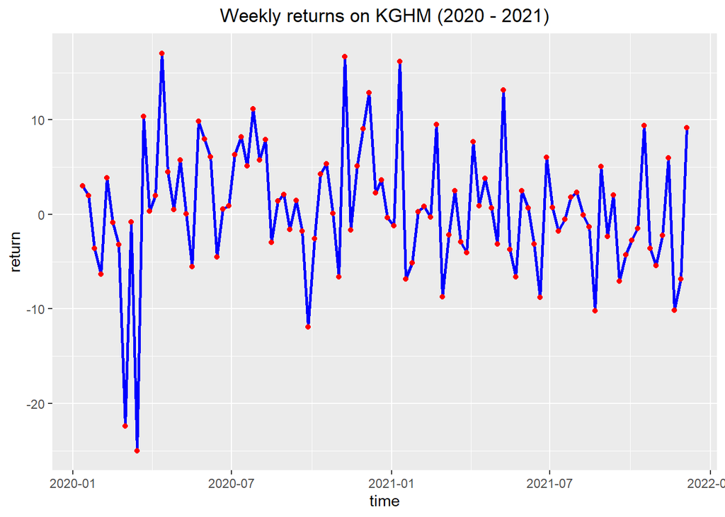

```r
data4 <- data.frame(
  day = as.Date(kgh_w_2020$Data[-1]),
  value = rate_of_return_w_2020_s
)

ggplot(data = data4, aes(x = day, y = value)) +
  geom_line(color = "blue", size = 1) +
  geom_point(color="red") +
  ggtitle("Weekly returns on KGHM (2020 - 2021)") +
  theme(plot.title = element_text(hjust = 0.5)) +
  labs(x = "time", y = "return")
```

### Logarytmiczna tygodniowa stopa zwrotu z lat 2020 - 2021

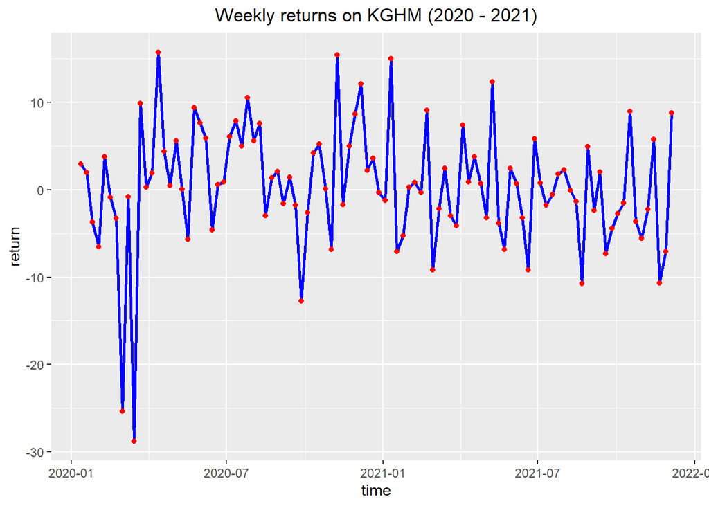

```r
data5 <- data.frame(
  day = as.Date(kgh_w_2020$Data[-1]),
  value = rate_of_return_w_2020_l
)

ggplot(data = data5, aes(x = day, y = value)) +
  geom_line(color = "blue", size = 1) +
  geom_point(color="red") +
  ggtitle("Weekly returns on KGHM (2020 - 2021)") +
  theme(plot.title = element_text(hjust = 0.5)) +
  labs(x = "time", y = "return")
```

### Różnica między tygodniowa stopą prostą i logarytmiczną z lat 2020 - 2021

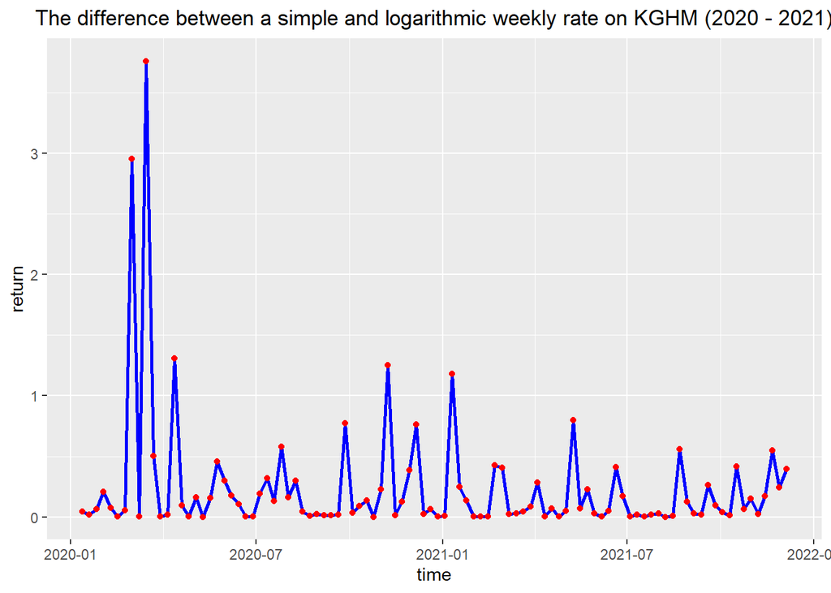

```r
data6 <- data.frame(
  day = as.Date(kgh_w_2020$Data[-1]),
  value = rate_of_return_w_2020_s - rate_of_return_w_2020_l
)

ggplot(data = data6, aes(x = day, y = value)) +
  geom_line(color = "blue", size = 1) +
  geom_point(color="red") +
  ggtitle("The difference between a simple and logarithmic weekly rate on KGHM (2020 - 2021)") +
  theme(plot.title = element_text(hjust = 0.5)) +
  labs(x = "time", y = "return")
```

### Prosta miesieczna stopa zwrotu z lat 2009 - 2021

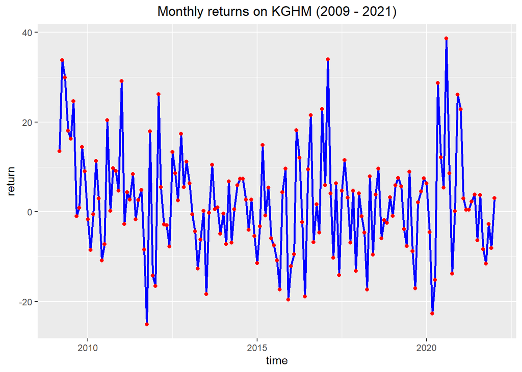

```r
data7 <- data.frame(
  day = as.Date(kgh_m_2009$Data[-1]),
  value = rate_of_return_m_2009_s
)

ggplot(data = data7, aes(x = day, y = value)) +
  geom_line(color = "blue", size = 1) +
  geom_point(color="red") +
  ggtitle("Monthly returns on KGHM (2009 - 2021)") +
  theme(plot.title = element_text(hjust = 0.5)) +
  labs(x = "time", y = "return")
```

### Logarytmiczna miesieczna stopa zwrotu z lat 2009 - 2021

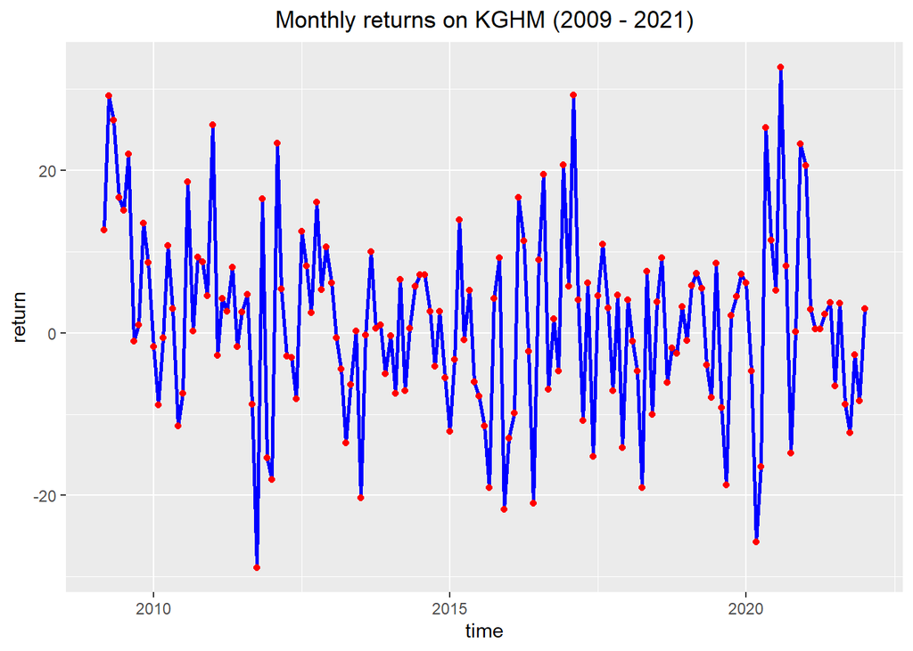

```r
data8 <- data.frame(
  day = as.Date(kgh_m_2009$Data[-1]),
  value = rate_of_return_m_2009_l
)

ggplot(data = data8, aes(x = day, y = value)) +
  geom_line(color = "blue", size = 1) +
  geom_point(color="red") +
  ggtitle("Monthly returns on KGHM (2009 - 2021)") +
  theme(plot.title = element_text(hjust = 0.5)) +
  labs(x = "time", y = "return")
```

### Różnica między miesieczna stopą prostą i logarytmiczną z lat 2009 - 2021

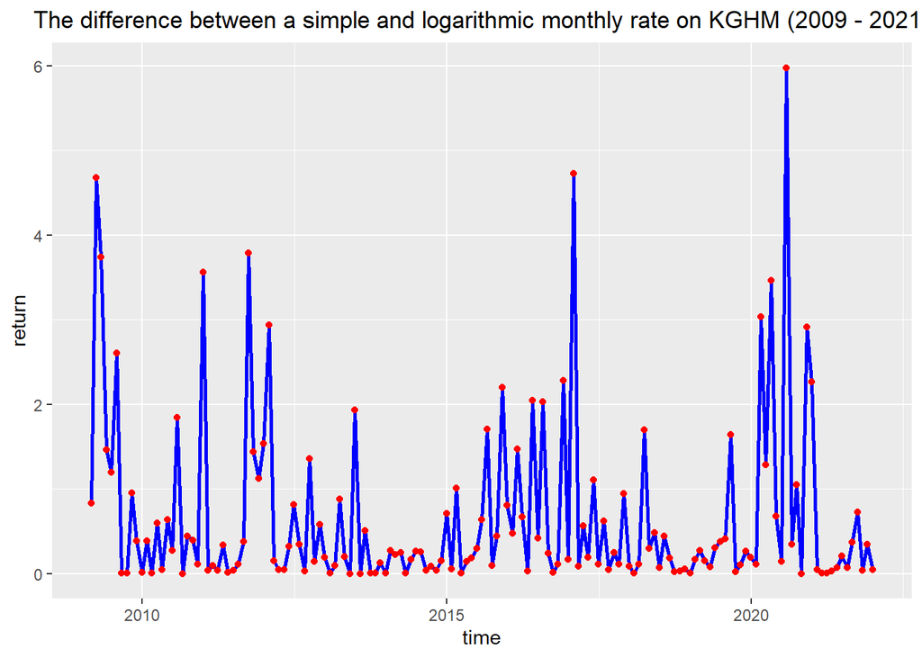

```r
data9 <- data.frame(
  day = as.Date(kgh_m_2009$Data[-1]),
  value = rate_of_return_m_2009_s - rate_of_return_m_2009_l
)

ggplot(data = data9, aes(x = day, y = value)) +
  geom_line(color = "blue", size = 1) +
  geom_point(color="red") +
  ggtitle("The difference between a simple and logarithmic monthly rate on KGHM (2009 - 2021)") +
  theme(plot.title = element_text(hjust = 0.5)) +
  labs(x = "time", y = "return")
```

**Interpretacja**

Zaprezentowane wykresy różnic dwóch rodzajów zwrotów wskazują, że logarytmiczne stopy zwrotu są zawsze mniejsze od prostych stóp zwrotu.

# Zadanie 2

## Shapiro-Wilk test

```r
# Daily logarithmic rates of return
shapiro.test(rate_of_return_d_2012_l)
```

```
##
##  Shapiro-Wilk normality test
##
## data:  rate_of_return_d_2012_l
## W = 0.98522, p-value = 8.006e-05
```

```r
shapiro.test(rate_of_return_d_2020_l)
```

```
##
##  Shapiro-Wilk normality test
##
## data:  rate_of_return_d_2020_l
## W = 0.96729, p-value = 6.695e-09
```

```r
# Weekly logarithmic rates of return
shapiro.test(rate_of_return_w_2012_l)
```

```
##
##  Shapiro-Wilk normality test
##
## data:  rate_of_return_w_2012_l
## W = 0.90782, p-value = 2.272e-06
```

```r
shapiro.test(rate_of_return_w_2020_l)
```

```
##
##  Shapiro-Wilk normality test
##
## data:  rate_of_return_w_2020_l
## W = 0.9374, p-value = 0.0001342
```

```r
# Monthly logarithmic rates of return
shapiro.test(rate_of_return_m_2009_l)
```

```
##
##  Shapiro-Wilk normality test
##
## data:  rate_of_return_m_2009_l
## W = 0.9902, p-value = 0.3585
```

**Interpretacja**

Badanie normalności rozkładu logarytmicznych stóp zwrotu przeprowadzane jest w teście Shapiro-Wilka przy poziomie istotności 0.05. Hipotezą zerową jest normalność sprawdzanego rozkładu zmiennej. Wartość p-value w pierwszym teście wynosi 8.006e-05 i jest mniejsza od alfy, co oznacza odrzucenie hipotezy zerowej. Rozkład dziennej stopy zwrotu z lat 2012-2013 nie jest normalny. Wartość p-value w drugim teście wynosi 6.695e-09 i jest mniejsza od alfy, co oznacza odrzucenie hipotezy zerowej. Rozkład dziennej stopy zwrotu z lat 2020-2021 nie jest normalny. Wartość p-value w pierwszym teście wynosi 2.272e-06 i jest mniejsza od alfy, co oznacza odrzucenie hipotezy zerowej. Rozkład tygodniowej stopy zwrotu z lat 2012-2013 nie jest normalny. Wartość p-value w pierwszym teście wynosi 0.0001342 i jest mniejsza od alfy, co oznacza odrzucenie hipotezy zerowej. Rozkład tygodniowej stopy zwrotu z lat 2020-2021 nie jest normalny. Wartość p-value w pierwszym teście wynosi 0.3585 i jest większa od alfy, co oznacza nie odrzucenie hipotezy zerowej. Rozkład miesięcznej stopy zwrotu z lat 2009-2021 jest normalny.

## Anderson-Darling test

```r
library(nortest)

# Daily logarithmic rates of return
ad.test(rate_of_return_d_2012_l)
```

```
##
##  Anderson-Darling normality test
##
## data:  rate_of_return_d_2012_l
## A = 1.1717, p-value = 0.004606
```

```r
ad.test(rate_of_return_d_2020_l)
```

```
##
##  Anderson-Darling normality test
##
## data:  rate_of_return_d_2020_l
## A = 2.8818, p-value = 2.971e-07
```

```r
# Weekly logarithmic rates of return
ad.test(rate_of_return_w_2012_l)
```

```
##
##  Anderson-Darling normality test
##
## data:  rate_of_return_w_2012_l
## A = 1.0897, p-value = 0.007075
```

```r
ad.test(rate_of_return_w_2020_l)
```

```
##
##  Anderson-Darling normality test
##
## data:  rate_of_return_w_2020_l
## A = 0.98477, p-value = 0.01286
```

```r
# Monthly logarithmic rates of return
ad.test(rate_of_return_m_2009_l)
```

```
##
##  Anderson-Darling normality test
##
## data:  rate_of_return_m_2009_l
## A = 0.56486, p-value = 0.1414
```

**Interpretacja**

Badanie normalności rozkładu logarytmicznych stóp zwrotu przeprowadzane jest w teście Andersona-Darlinga przy poziomie istotności 0.05. Hipotezą zerową jest normalność sprawdzanego rozkładu zmiennej. Wartość p-value w pierwszym teście wynosi 0.004606 i jest mniejsza od alfy, co oznacza odrzucenie hipotezy zerowej. Rozkład dziennej stopy zwrotu z lat 2012-2013 nie jest normlany. Wartość p-value w drugim teście wynosi 2971e-07 i jest mniejsza od alfy, co oznacza odrzucenie hipotezy zerowej. Rozkład dziennej stopy zwrotu z lat 2020-2021 nie jest normlany. Wartość p-value w pierwszym teście wynosi 0.007075 i jest mniejsza od alfy, co oznacza odrzucenie hipotezy zerowej. Rozkład tygodniowej stopy zwrotu z lat 2012-2013 nie jest normlany. Wartość p-value w pierwszym teście wynosi 0.01286 i jest mniejsza od alfy, co oznacza odrzucenie hipotezy zerowej. Rozkład tygodniowej stopy zwrotu z lat 2020-2021 nie jest normlany. Wartość p-value w pierwszym teście wynosi 0.1414 i jest większa od alfy, co oznacza nie odrzucenie hipotezy zerowej. Rozkład miesięcznej stopy zwrotu z lat 2009-2021 jest normlany.

## Jarque-Bera test

```r
library(tseries)
library(DescTools)
# Daily logarithmic rates of return
jarque.bera.test(rate_of_return_d_2012_l)
```

```
##
##  Jarque Bera Test
##
## data:  rate_of_return_d_2012_l
## X-squared = 49.506, df = 2, p-value = 1.777e-11
```

```r
jarque.bera.test(rate_of_return_d_2020_l)
```

```
##
##  Jarque Bera Test
##
## data:  rate_of_return_d_2020_l
## X-squared = 209.35, df = 2, p-value < 2.2e-16
```

```r
# Weekly logarithmic rates of return
JarqueBeraTest(rate_of_return_w_2020_l, robust = TRUE, method = c("chisq", "mc"), N = 0, na.rm = FALSE)
```

```
##
##  Robust Jarque Bera Test
##
## data:  rate_of_return_w_2020_l
## X-squared = 98.392, df = 2, p-value < 2.2e-16
```

```r
jarque.bera.test(rate_of_return_w_2020_l)
```

```
##
##  Jarque Bera Test
##
## data:  rate_of_return_w_2020_l
## X-squared = 61.371, df = 2, p-value = 4.718e-14
```

```r
# Monthly logarithmic rates of return
jarque.bera.test(rate_of_return_m_2009_l)
```

```
##
##  Jarque Bera Test
##
## data:  rate_of_return_m_2009_l
## X-squared = 0.86002, df = 2, p-value = 0.6505
```

**Interpretacja**

**Zaprezentowane wyniki pokazują, że dzienne oraz tygodniowe logatrytmiczne stopy zwrotu nie mają rozkładu normalnego. Miesięczne stopy zwrotu sa normalnie rozlozone**

# Zadanie 3

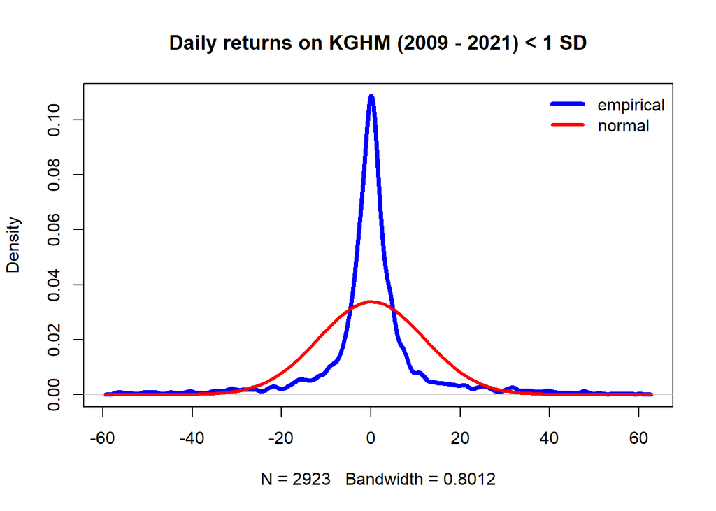

```r
data0 <- as.data.frame(kgh_d_2009)
close_d_2009 <- rev(data0$Ostatnio)
close_d_2009 <- as.double(factor(close_d_2009))
rate_of_return_d_2009_l <- rep(0, 3040)
for(i in 1:3040){
  rate_of_return_d_2009_l[i] = 100 * log(close_d_2009[i + 1]/close_d_2009[i])
}

m = mean(rate_of_return_d_2009_l)
s = sd(rate_of_return_d_2009_l)

rate_of_return_d_2009_1sd <- c()
for(i in 1:3040){
  if(rate_of_return_d_2009_l[i] < m && rate_of_return_d_2009_l[i] > (m - s) | rate_of_return_d_2009_l[i] > m && rate_of_return_d_2009_l[i] < (m + s)){
    rate_of_return_d_2009_1sd <- append(rate_of_return_d_2009_1sd, rate_of_return_d_2009_l[i])
  }
}

plot(density(rate_of_return_d_2009_1sd),col='blue',lwd=4, main = "Daily returns on KGHM (2009 - 2021) < 1 SD")
curve(dnorm(x, mean(rate_of_return_d_2009_1sd),sd(rate_of_return_d_2009_1sd)),add=TRUE,col='red',lwd=3)
legend("topright",bg='white',bty="n",cex=1,lty=1,lwd=c(4,3),
       c('empirical','normal'),col=c('blue','red'))
```

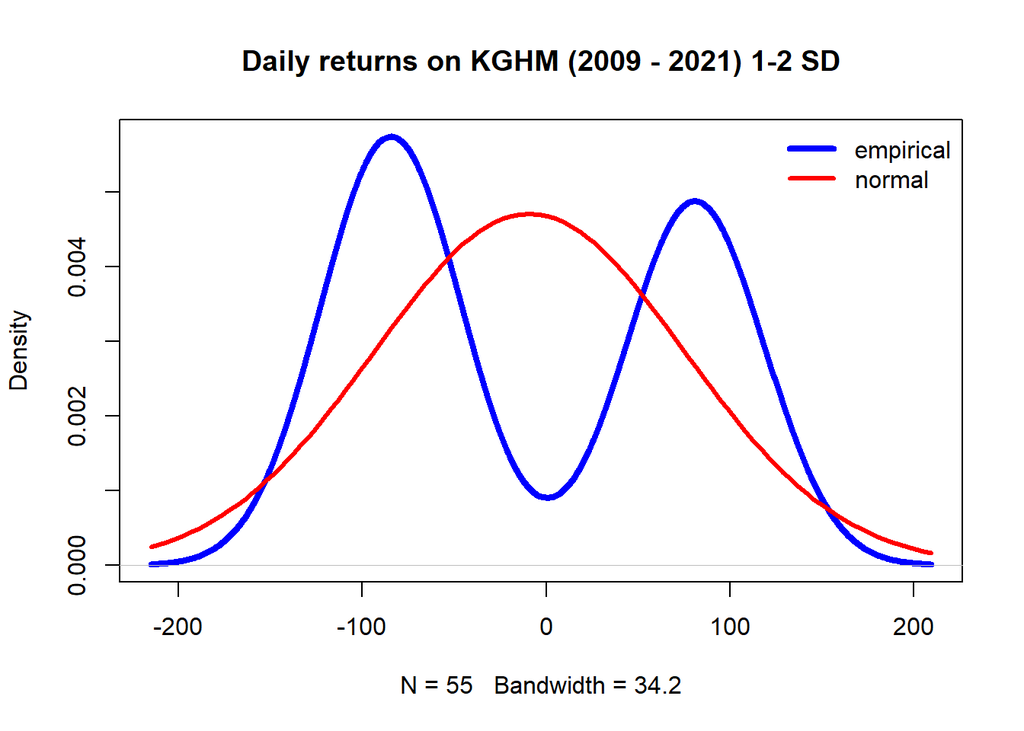

```r
rate_of_return_d_2009_1_2sd <- c()
for(i in 1:3040){
  if(rate_of_return_d_2009_l[i] < (m - s) && rate_of_return_d_2009_l[i] > (m - 2*s) | rate_of_return_d_2009_l[i] > (m+ s) && rate_of_return_d_2009_l[i] < (m + 2*s)){
    rate_of_return_d_2009_1_2sd <- append(rate_of_return_d_2009_1_2sd, rate_of_return_d_2009_l[i])
  }
}

plot(density(rate_of_return_d_2009_1_2sd),col='blue',lwd=4, main = "Daily returns on KGHM (2009 - 2021) 1-2 SD")
curve(dnorm(x, mean(rate_of_return_d_2009_1_2sd),sd(rate_of_return_d_2009_1_2sd)),add=TRUE,col='red',lwd=3)
legend("topright",bg='white',bty="n",cex=1,lty=1,lwd=c(4,3),
       c('empirical','normal'),col=c('blue','red'))
```

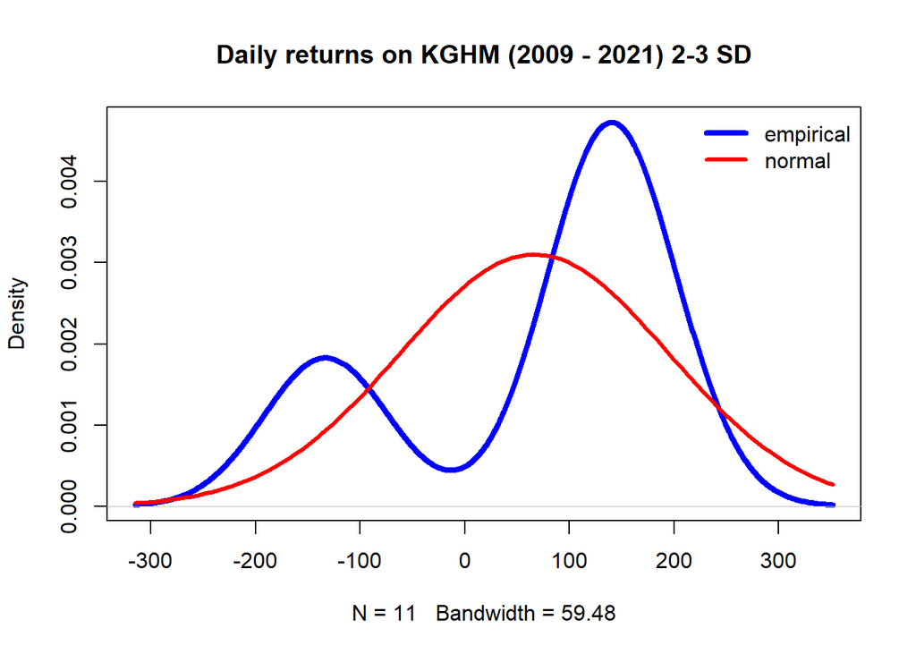

```r
rate_of_return_d_2009_2_3sd <- c()
for(i in 1:3040){
  if(rate_of_return_d_2009_l[i] < (m - 2*s) && rate_of_return_d_2009_l[i] > (m - 3*s) | rate_of_return_d_2009_l[i] > (m + 2*s) && rate_of_return_d_2009_l[i] < (m + 3*s)){
    rate_of_return_d_2009_2_3sd <- append(rate_of_return_d_2009_2_3sd, rate_of_return_d_2009_l[i])
  }
}

plot(density(rate_of_return_d_2009_2_3sd),col='blue',lwd=4, main = "Daily returns on KGHM (2009 - 2021) 2-3 SD")
curve(dnorm(x, mean(rate_of_return_d_2009_2_3sd),sd(rate_of_return_d_2009_2_3sd)),add=TRUE,col='red',lwd=3)
legend("topright",bg='white',bty="n",cex=1,lty=1,lwd=c(4,3),
       c('empirical','normal'),col=c('blue','red'))
```

```r
rate_of_return_d_2009_3_4sd <- c()
for(i in 1:3040){
  if(rate_of_return_d_2009_l[i] < (m - 3*s) && rate_of_return_d_2009_l[i] > (m - 4*s) | rate_of_return_d_2009_l[i] > (m + 3*s) && rate_of_return_d_2009_l[i] < (m + 4*s)){
    rate_of_return_d_2009_2_3sd <- append(rate_of_return_d_2009_2_3sd, rate_of_return_d_2009_l[i])
  }
}

#plot(density(rate_of_return_d_2009_3_4sd),col='blue',lwd=4, main = "Daily returns on KGHM (2009 - 2021) 3-4 SD")
#curve(dnorm(x, mean(rate_of_return_d_2009_3_4sd),sd(rate_of_return_d_2009_3_4sd)),add=TRUE,col='red',lwd=3)
#legend("topright",bg='white',bty="n",cex=1,lty=1,lwd=c(4,3),
       #c('empirical','normal'),col=c('blue','red'))
```

W tym przypadku wizualizacja nie jest mozliwa ze zwgledu na fakt, że tylko jeden punkt spelnia kruterium 3-4 SD.

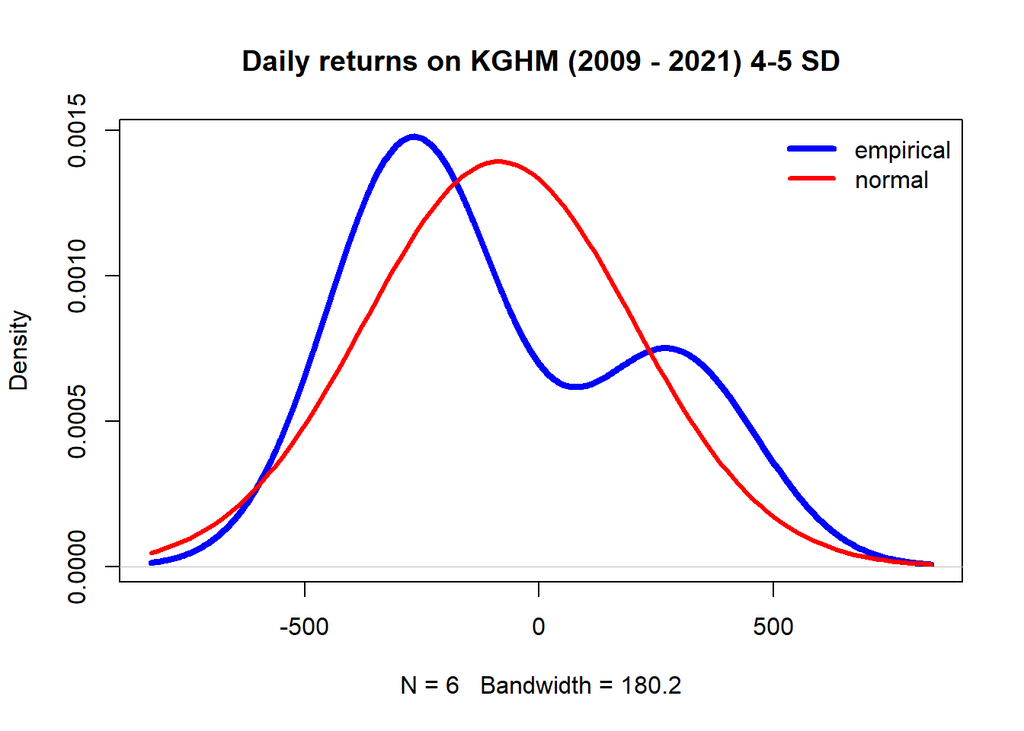

```r
rate_of_return_d_2009_4_5sd <- c()
for(i in 1:3040){
  if(rate_of_return_d_2009_l[i] < (m - 4*s) && rate_of_return_d_2009_l[i] > (m - 5*s) | rate_of_return_d_2009_l[i] > (m+ 4*s) && rate_of_return_d_2009_l[i] < (m + 5*s)){
    rate_of_return_d_2009_4_5sd <- append(rate_of_return_d_2009_4_5sd, rate_of_return_d_2009_l[i])
  }
}

plot(density(rate_of_return_d_2009_4_5sd),col='blue',lwd=4, main = "Daily returns on KGHM (2009 - 2021) 4-5 SD")
curve(dnorm(x, mean(rate_of_return_d_2009_4_5sd),sd(rate_of_return_d_2009_4_5sd)),add=TRUE,col='red',lwd=3)
legend("topright",bg='white',bty="n",cex=1,lty=1,lwd=c(4,3),
       c('empirical','normal'),col=c('blue','red'))
```

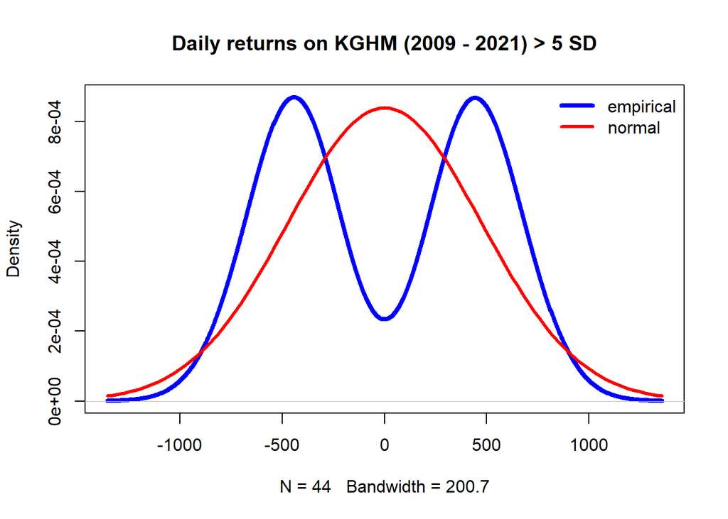

```r
rate_of_return_d_2009_5sd <- c()
for(i in 1:3040){
  if(rate_of_return_d_2009_l[i] < (m - 5*s) | rate_of_return_d_2009_l[i] > (m + 5*s)){
    rate_of_return_d_2009_5sd <- append(rate_of_return_d_2009_5sd, rate_of_return_d_2009_l[i])
  }
}

plot(density(rate_of_return_d_2009_5sd),col='blue',lwd=4, main = "Daily returns on KGHM (2009 - 2021) > 5 SD")
curve(dnorm(x, mean(rate_of_return_d_2009_5sd),sd(rate_of_return_d_2009_5sd)),add=TRUE,col='red',lwd=3)
legend("topright",bg='white',bty="n",cex=1,lty=1,lwd=c(4,3),
       c('empirical','normal'),col=c('blue','red'))
```

**Interpretacja**

Zaprezentowane wykresy pokazują, że w przypadku wartości stóp zwrotu oddalonych o wiecej niż 5 odchyleń standardowych od średniej, można mówić o symetrycznych wzrostach i spadkach cen. Dzieje się tak, ponieważ rozkład normalny (dla zwrotów prostych) jest symetryczny. Rozkład log-normalny (logarytmicznych zwrotów) nie jest. Jest lekko przekrzywiony, przy czym dążąc ku nieskończonosci zbliza sie do zera, więc dla dużych wartości stóp zwrotu ta symetria może już występować.

# Zadanie 4

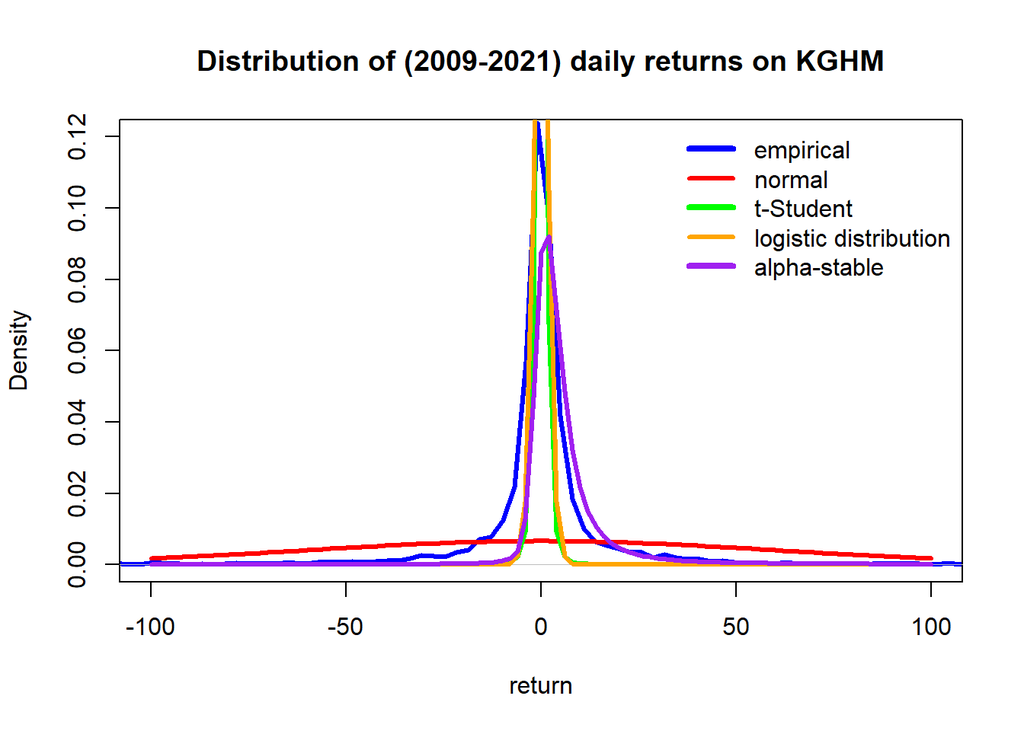

```r
library(stabledist)
plot(density(rate_of_return_d_2009_l),col='blue',lwd=3,main='Distribution of (2009-2021) daily returns on KGHM', xlim = c(-100, 100), ylim = c(0, 0.12), xlab = "return")
curve(dnorm(x, mean(rate_of_return_d_2009_l),sd(rate_of_return_d_2009_l)),add=TRUE,col='red',lwd=3)
curve(dt(x, df = 3),add=TRUE,col='green',lwd=3)
curve(dlogis(x),add=TRUE,col='orange',lwd=3)
curve(dstable(x, alpha=1.2, beta = .8, gamma = 3, delta = 2), -100, 100, col="purple", lwd=3,add=TRUE)
legend("topright",bg='white',bty="n",cex=1,lty=1,lwd=c(4,3),
       c('empirical','normal','t-Student','logistic distribution','alpha-stable'),col=c('blue','red','green','orange','purple'))
```

**Interpretacja**

Analizując wykres można zauważyć, że najlepiej do rozkładu stóp zwrotu pasowalby rozkład alfa-stabilny.